# Measurement models

```r
library(ctsem)
library(ggplot2)
```

A ctsem model has two halves. The **dynamic** half says how the latent processes evolve between observations; the **measurement** half says how an observation at a time point relates to the latent state then. This vignette is entirely about the second half: how many indicators load on a process, what kind of variable each indicator is, what happens when kinds are mixed, and what to do when a loading or a residual is not a constant.

Everything here uses `backend = 'julia'`. The non-Gaussian indicator types (ordinal, count, censored) exist only on that backend, and binary is *integrated* there rather than linearised, so a vignette that switched backends between sections would not be comparing like with like.

# The measurement equation

At each observed time point the filter has a predicted latent state $\eta$. For every manifest variable $j$ observed at that row, ctsem forms a linear predictor

$$\mu_j \;=\; \text{MANIFESTMEANS}_j \;+\; \text{LAMBDA}_{j\cdot}\, \eta$$

and then attaches an observation model to it, chosen by that variable’s `manifesttype`:

| `manifesttype` | Variable | Observation model | Residual |
| --- | --- | --- | --- |
| `0` | continuous | $y_j \sim N(\mu_j,\ \text{MANIFESTVAR})$ | free |
| `1` | binary, coded 0/1 | $P(y_j = 1) = \text{logit}^{-1}(\mu_j)$ | none |
| `2` | ordinal, coded $1..K$ | $P(y_j \le k) = \text{logit}^{-1}(\tau_{jk} - \mu_j)$ | none |
| `3` | count, non-negative integers | $y_j \sim \text{Poisson}(e^{\mu_j + e_j})$, $e_j \sim N(0, \text{MANIFESTVAR})$ | free |
| `4` | censored | $N(\mu_j,\ \text{MANIFESTVAR})$, observed only inside $[\,c^-_j, c^+_j\,]$ | free |

Four things follow from that table and are worth stating before any code.

**Binary and ordinal indicators have no residual variance.** Their randomness is entirely in the link, and a term added to the linear predictor would not be identified if you wanted one: under a probit link $E_e\,\Phi(\mu_j + e) = \Phi(\mu_j / \sqrt{1 + v})$ exactly, so such a term is absorbed into the loadings and thresholds, and the logistic link differs only in that the absorption is approximate. Their rows and columns of `MANIFESTVAR` are fixed to zero, and `ctFit()` fixes any that were left free.

**The other three do have one, and it means something different in each.** For a continuous indicator it is the usual measurement error variance. For a censored one it is the variance of the Gaussian that is observed only inside the limits. For a count it is a *dispersion*: a Gaussian term added to the log rate, making the observation Poisson-lognormal rather than Poisson. It is identified where the binary and ordinal versions of it are not, because a Poisson’s variance is locked to its mean — the dispersion shifts the mean by $v/2$, which `MANIFESTMEANS` absorbs, and multiplies the variance by a factor nothing else in the model can produce. It is the only parameter in a ctsem model that moves a count’s variance-to-mean ratio, and leaving it out does not make the data equidispersed: it makes `DIFFUSION` absorb the difference, which is usually the parameter the model was for. Only the diagonal counts — a count row is scored on its own, so it has no correlated measurement error, and `ctFit()` fixes a free off-diagonal to zero.

**The scale of the latent process has to come from somewhere.** With a Gaussian indicator you can anchor it by fixing a loading, or by fixing `DIFFUSION`. With only binary or ordinal indicators there is no free residual to trade against, so a loading and the process scale are two names for one quantity: fix the loadings and let `DIFFUSION` carry the scale.

**Location works the same way.** `CINT` and `T0MEANS` set where the process sits, and each indicator’s `MANIFESTMEANS` sets where that indicator sits relative to it. ctsem’s default fixes `CINT` and `T0MEANS` to zero and frees `MANIFESTMEANS`, which is what the examples below use — ordinal indicators included. An ordinal indicator’s thresholds are *also* locations, so one among them is redundant: adding a constant to $\mu_j$ and to every $\tau_{jk}$ leaves the cumulative logit unchanged. ctsem resolves that by pinning $\tau_{j1}$ at zero, so the location of an ordinal indicator lives in its `MANIFESTMEANS` like everyone else’s, and what `THRESHOLDS` estimates is the K-2 gaps between successive thresholds. The point of putting it there rather than in $\tau_{j1}$ is that `MANIFESTMEANS` can be `indvarying`: one random effect then shifts all of an indicator’s category boundaries together, which is what “this person answers higher” means, where a random effect on the thresholds would need one per boundary.

# One indicator or many

A univariate Ornstein-Uhlenbeck process, measured three times over at each occasion with loadings 1, 0.8 and 1.2:

```r
set.seed(3)
genmulti <- ctModel(type = 'ct', n.latent = 1, n.manifest = 3,
  manifestNames = c('y1', 'y2', 'y3'), latentNames = 'eta1',
  LAMBDA = matrix(c(1, 0.8, 1.2), 3, 1),
  DRIFT = matrix(-0.4), DIFFUSION = matrix(1.5), T0VAR = matrix(1.7),
  T0MEANS = matrix(0), CINT = matrix(0),
  MANIFESTMEANS = matrix(c(0, 0.5, -0.5), 3, 1),
  MANIFESTVAR = diag(0.8, 3), Tpoints = 10)

dmulti <- data.frame(ctGenerate(genmulti, n = 50, Tpoints = 10,
  backend = 'julia'))
head(dmulti, 3)
```

```
#>   id time        y1         y2        y3
#> 1  1    0 -3.347169 -1.8190194 -2.395708
#> 2  1    1 -1.309557 -0.5163224 -2.078168
#> 3  1    2 -1.175804  0.1784173 -1.663167
```

## A single indicator

With one indicator per process the loading is not estimable and is fixed, by convention to 1. That does *not* mean measurement error is inestimable: in a continuous time model the measurement error and the process innovation have different signatures across the time interval, so `MANIFESTVAR` and `DIFFUSION` remain separately identified.

```r
msingle <- ctModel(type = 'ct', n.latent = 1, n.manifest = 1,
  manifestNames = 'y1', latentNames = 'eta1', LAMBDA = matrix(1),
  CINT = matrix(0), T0MEANS = matrix(0))
msingle$pars$indvarying <- FALSE

fsingle <- ctFit(dmulti, msingle, backend = 'julia', cores = 2)
summary(fsingle)$popmeans
```

```
#>              mean    sd   2.5%    50%  97.5%
#> drift_eta1 -0.328 0.092 -0.533 -0.316 -0.186
#> diff_eta1   1.347 0.214  0.968  1.325  1.798
#> mvary1      0.972 0.132  0.738  0.964  1.258
#> mm_y1       0.053 0.160 -0.252  0.061  0.368
#> T0var_eta1  1.670 0.239  1.245  1.656  2.187
```

## Three indicators

Freeing the two remaining loadings and keeping the first at 1 makes `eta1` a common factor. The first indicator’s scale is now the latent’s scale, which is what the fixed 1 buys:

```r
mmulti <- ctModel(type = 'ct', n.latent = 1, n.manifest = 3,
  manifestNames = c('y1', 'y2', 'y3'), latentNames = 'eta1',
  LAMBDA = matrix(c(1, 'lambda_y2', 'lambda_y3'), 3, 1),
  CINT = matrix(0), T0MEANS = matrix(0))
mmulti$pars$indvarying <- FALSE

fmulti <- ctFit(dmulti, mmulti, backend = 'julia', cores = 2)
summary(fmulti)$popmeans
```

```
#>              mean    sd   2.5%    50%  97.5%
#> lambda_y2   0.794 0.027  0.742  0.793  0.846
#> lambda_y3   1.192 0.034  1.127  1.192  1.257
#> drift_eta1 -0.414 0.058 -0.539 -0.412 -0.310
#> diff_eta1   1.589 0.082  1.439  1.589  1.750
#> mvary1      0.798 0.037  0.729  0.798  0.874
#> mvary2      0.784 0.032  0.722  0.784  0.846
#> mvary3      0.756 0.047  0.667  0.756  0.851
#> mm_y1       0.071 0.150 -0.222  0.069  0.366
#> mm_y2       0.615 0.123  0.376  0.611  0.856
#> mm_y3      -0.416 0.180 -0.761 -0.416 -0.060
#> T0var_eta1  1.751 0.191  1.419  1.740  2.155
```

The loadings come back near their generating values, and the dynamic parameters are estimated more sharply than from one indicator alone:

```r
s1 <- summary(fsingle)$popmeans
s3 <- summary(fmulti)$popmeans
pars <- c('drift_eta1', 'diff_eta1')
data.frame(
  parameter = pars,
  truth = c(-0.4, 1.5),
  single = s1[pars, 'mean'], single_se = s1[pars, 'sd'],
  three = s3[pars, 'mean'], three_se = s3[pars, 'sd'],
  row.names = NULL)
```

```
#>    parameter truth single single_se  three three_se
#> 1 drift_eta1  -0.4 -0.328     0.092 -0.414    0.058
#> 2  diff_eta1   1.5  1.347     0.214  1.589    0.082
```

> **Anchoring, and where the optimiser starts**

> Fixing `LAMBDA[1,1]` is not the only way to set the scale — fixing `DIFFUSION` to 1 and freeing all three loadings fits the same model, and reports loadings on the process’s own scale instead of on `y1`’s.

> The two are equivalent in principle but not always in practice, because where the optimiser starts matters. `ctFit` reads the starting values for the variance diagonals off the data by default, through `optimcontrol$datastart`. Before that it began every fit from a fixed point that put `DIFFUSION` near 7 whatever the data were measured in, and on data at a much smaller scale a loading-anchored model would collapse the latent to zero variance and explain the whole signal as measurement error — a local optimum, with the loadings running off to implausible magnitudes to compensate. On the data above rescaled by 1/100 that failed on four starting seeds out of four, and converges on four out of four now.

> It is not a guarantee. A model can sit near a basin boundary at a given scale, where the small random jitter ctsem still adds to the start is enough to decide which optimum the fit reaches — on the same data rescaled by 100, two seeds in four land 328 log units apart, with or without the derived start. So a fit reporting non-convergence, or loadings nowhere near anything plausible, is worth re-running, and worth checking against `DIFFUSION`-anchored scaling or explicit `inits`.

# The five indicator types

To see each type on its own, generate one latent trajectory and then measure it five different ways. Generating the process with a near-zero measurement variance makes the single manifest variable a direct readout of the latent state, which the indicators below are built from:

```r
set.seed(5)
nsub <- 80; nobs <- 10
process <- ctModel(type = 'ct', n.latent = 1, n.manifest = 1,
  manifestNames = 'eta', latentNames = 'eta1', LAMBDA = matrix(1),
  DRIFT = matrix(-0.4), DIFFUSION = matrix(1), T0VAR = matrix(1.12),
  T0MEANS = matrix(0), CINT = matrix(0), MANIFESTMEANS = matrix(0),
  MANIFESTVAR = matrix(1e-6), Tpoints = nobs)

d <- data.frame(ctGenerate(process, n = nsub, Tpoints = nobs,
  backend = 'r'))
eta <- d$eta
```

Two indicators of each kind, built by applying each row of the table above by hand, so that the link in the model and the link in the simulation are visibly the same thing:

```r
invlogit <- function(x) 1 / (1 + exp(-x))
ordinaldraw <- function(mu, tau) {          # cumulative logit
  cum <- sapply(tau, function(k) invlogit(k - mu))
  p <- cbind(cum, 1)
  p <- cbind(p[, 1, drop = FALSE], t(apply(p, 1, diff)))
  apply(p, 1, function(pr) sample.int(length(pr), 1, prob = pmax(pr, 0)))
}
tau <- c(-1, 0, 1)                          # four categories

d$y1 <- 0.0 + eta + rnorm(nrow(d), 0, 0.6)              # 0 continuous
d$y2 <- 0.5 + eta + rnorm(nrow(d), 0, 0.6)
d$b1 <- rbinom(nrow(d), 1, invlogit(-0.4 + eta))        # 1 binary
d$b2 <- rbinom(nrow(d), 1, invlogit( 0.4 + eta))
d$o1 <- ordinaldraw(eta, tau)                           # 2 ordinal
d$o2 <- ordinaldraw(eta, tau)
disp <- 0.3                                 # count dispersion, on the log rate
d$c1 <- rpois(nrow(d),                                  # 3 count
  exp(1.4 + 0.5 * eta + rnorm(nrow(d), 0, disp)))
d$c2 <- rpois(nrow(d), exp(1.2 + 0.5 * eta + rnorm(nrow(d), 0, disp)))
d$x1 <- pmin(pmax(2.0 + eta + rnorm(nrow(d), 0, 0.5), 0), 4)   # 4 censored
d$x2 <- pmin(pmax(1.8 + eta + rnorm(nrow(d), 0, 0.5), 0), 4)

d$eta <- NULL
head(d, 3)
```

```
#>   id time           y1          y2 b1 b2 o1 o2 c1 c2        x1        x2
#> 1  1    0 -1.426062341  0.59163773  0  0  2  3  4  1 0.6966535 0.5905002
#> 2  1    1  1.752632464  0.03085567  1  1  2  4  5  3 2.3802010 1.5137950
#> 3  1    2  0.006634949 -0.84232851  1  0  2  4  1  5 0.9411608 1.0590349
```

One subject, seen through all five instruments at once:

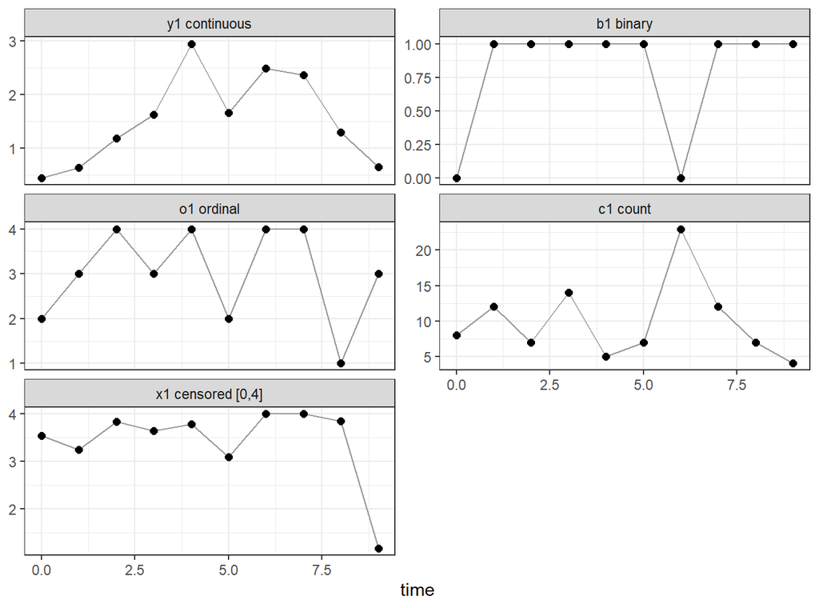

```r
shown <- c('y1', 'b1', 'o1', 'c1', 'x1')
long <- do.call(rbind, lapply(shown, function(v)
  data.frame(time = d$time[d$id == 2], value = d[[v]][d$id == 2],
    indicator = v)))
long$indicator <- factor(long$indicator, levels = shown,
  labels = c('y1 continuous', 'b1 binary', 'o1 ordinal', 'c1 count',
    'x1 censored [0,4]'))

ggplot(long, aes(time, value)) +
  geom_line(colour = 'grey60') + geom_point(size = 2) +
  facet_wrap(~indicator, scales = 'free_y', ncol = 2) +
  theme_bw() + labs(x = 'time', y = NULL)
```

## Specifying each type

`manifesttype` is a vector with one entry per manifest variable. Two of the types need something extra alongside it, and both are needed because `ctModel()` never sees the data:

- **ordinal** needs `ncategories`, so that the right number of thresholds can be created. `ctGenerate()` needs it for the same reason.
- **censored** needs `censormin` and `censormax`. These are known constants rather than parameters: an instrument’s floor and ceiling are properties of the instrument, and the data cannot inform them. A variable censored on one side only leaves the other infinite.

A helper, since the five models below differ only in which columns they take:

```r
buildmodel <- function(names, type, lambda = 1, ncat = 0,
  cmin = -Inf, cmax = Inf) {
  n <- length(names)
  # binary and ordinal are the two types with no residual of any kind
  mvar <- diag(0, n)
  if (type %in% c(0, 3, 4)) diag(mvar) <- paste0('mvar_', names)
  m <- ctModel(type = 'ct', n.latent = 1, n.manifest = n,
    manifestNames = names, latentNames = 'eta1',
    manifesttype = rep(type, n), ncategories = rep(ncat, n),
    censormin = rep(cmin, n), censormax = rep(cmax, n),
    LAMBDA = matrix(lambda, n, 1),
    MANIFESTMEANS = matrix(paste0('mm_', names), n, 1), MANIFESTVAR = mvar,
    CINT = matrix(0), T0MEANS = matrix(0))
  m$pars$indvarying <- FALSE
  m
}

models <- list(
  continuous = buildmodel(c('y1', 'y2'), 0),
  binary     = buildmodel(c('b1', 'b2'), 1),
  ordinal    = buildmodel(c('o1', 'o2'), 2, ncat = 4),
  count      = buildmodel(c('c1', 'c2'), 3, lambda = 0.5),
  censored   = buildmodel(c('x1', 'x2'), 4, cmin = 0, cmax = 4))
```

Every one of these fixes its loadings rather than freeing them, so that the latent scale is anchored the same way in all five and the dynamic estimates below can be read side by side.

The count pair is fixed at 0.5 rather than 1, and that is a choice worth making deliberately. A count’s loading sets how far its *log* rate travels as the process moves, and the exponential turns a wide latent range into a very skewed observation. The filter carries a Gaussian summary of the state, and a Poisson update is well summarised that way only while the rate stays in a moderate range. Measured on this design at 200 subjects and 12 occasions: a count read directly off a process with a standard deviation of 1.12 – log rates spanning about seven units, rates from 0.05 to 50 – recovers `DRIFT` at -0.20 and -0.32 on two seeds against a generating -0.4, and `DIFFUSION` at 0.69 and 0.74 against 1. The same process at a standard deviation of 0.45 recovers -0.407 and -0.418, and its `DIFFUSION` to within 0.012. Halving the loading halves the range the link sees, which is why the count column below is as accurate as the others. If your counts genuinely do swing over orders of magnitude, treat the dynamic estimates from them with the same suspicion.

The count models here also estimate a `MANIFESTVAR` diagonal, which for a count is the dispersion rather than a measurement error: a Gaussian term on the log rate, so the observation is Poisson-lognormal. The counts above were generated with one, of 0.3. Freeing it is worth doing on real counts whatever you expect, because the alternative is not a Poisson assumption quietly satisfied — it is `DIFFUSION` absorbing whatever overdispersion there is, and `DIFFUSION` is usually the parameter the model was for.

## The same process, through five instruments

```r
fits <- lapply(models, function(m) ctFit(d, m, backend = 'julia', cores = 2))

pull <- function(f, p, what) summary(f)$popmeans[p, what]
data.frame(
  type = names(fits),
  drift = sapply(fits, pull, 'drift_eta1', 'mean'),
  drift_se = sapply(fits, pull, 'drift_eta1', 'sd'),
  diffusion = sapply(fits, pull, 'diff_eta1', 'mean'),
  diffusion_se = sapply(fits, pull, 'diff_eta1', 'sd'),
  row.names = NULL)
```

```
#>         type  drift drift_se diffusion diffusion_se
#> 1 continuous -0.442    0.052     1.052        0.049
#> 2     binary -0.289    0.119     0.698        0.230
#> 3    ordinal -0.346    0.113     0.888        0.188
#> 4      count -0.356    0.061     0.966        0.081
#> 5   censored -0.436    0.050     1.046        0.045
```

Every row of that table estimates the same two generating values, $-0.4$ and $1$, from the same latent trajectory, and every row is within about one standard error of them. What differs is how much of the trajectory each instrument transmits, which is visible in the standard errors rather than in the estimates: two binary items per occasion carry a few bits about a continuous state and are the least precise by a factor of two, while the continuous, censored and count pairs each recover `DRIFT` to about 0.05.

The parameters specific to a type appear in the same summary. An ordinal indicator’s location is in `MANIFESTMEANS`; `THRESHOLDS` holds the first threshold, pinned at zero and not reported, and then the **gap** to each subsequent one, which is what keeps them ordered. So a four category variable contributes one mean and two gaps:

```r
thr <- summary(fits$ordinal)$popmeans
gaps <- grep('threshold_o1', rownames(thr), value = TRUE)
thr[c('mm_o1', gaps), c('mean', 'sd')]
```

```
#>                 mean    sd
#> mm_o1          0.940 0.118
#> threshold_o1_2 0.999 0.079
#> threshold_o1_3 0.945 0.079
```

```r
# cumulate the gaps from the pinned zero, then subtract the mean, to read the
# thresholds on the latent scale
cumsum(c(0, thr[gaps, 'mean'])) - thr['mm_o1', 'mean']     # against c(-1, 0, 1)
```

```
#> [1] -0.940  0.059  1.004
```

A censored indicator’s residual standard deviation is the one that means what it usually means. The model recovers it from the uncensored part of the scale, while treating a value sitting at a limit as the probability of being there rather than as a density:

```r
summary(fits$censored)$popmeans[c('mvar_x1', 'mvar_x2', 'mm_x1', 'mm_x2'),
  c('mean', 'sd')]
```

```
#>          mean    sd
#> mvar_x1 0.485 0.027
#> mvar_x2 0.503 0.026
#> mm_x1   2.078 0.078
#> mm_x2   1.900 0.078
```

```r
mean(d$x1 %in% c(0, 4))     # proportion of x1 observations at a limit
```

```
#> [1] 0.10375
```

# Combining types

## Several types on one latent

Nothing stops indicators of different types from loading on the same process. Each contributes its own likelihood term against the same predicted state, and the filter’s update at that row takes all of them:

```r
mixednames <- c('y1', 'b1', 'o1', 'c1', 'x1')
mvar <- diag(0, 5)
mvar[1, 1] <- 'mvar_y1'      # measurement error
mvar[4, 4] <- 'mvar_c1'      # the count's dispersion
mvar[5, 5] <- 'mvar_x1'      # the scale inside the censoring limits

mmixed <- ctModel(type = 'ct', n.latent = 1, n.manifest = 5,
  manifestNames = mixednames, latentNames = 'eta1',
  manifesttype = c(0, 1, 2, 3, 4),
  ncategories   = c(0, 0, 4, 0, 0),
  censormin     = c(-Inf, -Inf, -Inf, -Inf, 0),
  censormax     = c( Inf,  Inf,  Inf,  Inf, 4),
  LAMBDA = matrix(c(1, 1, 1, 0.5, 1), 5, 1),   # the count as generated
  MANIFESTMEANS = matrix(paste0('mm_', mixednames), 5, 1),
  MANIFESTVAR = mvar, CINT = matrix(0), T0MEANS = matrix(0))
mmixed$pars$indvarying <- FALSE

fmixed <- ctFit(d, mmixed, backend = 'julia', cores = 2)
summary(fmixed)$popmeans
```

```
#>                  mean    sd   2.5%    50%  97.5%
#> drift_eta1     -0.450 0.049 -0.551 -0.449 -0.360
#> diff_eta1       1.036 0.044  0.949  1.036  1.119
#> mvar_y1         0.621 0.022  0.580  0.622  0.663
#> mvar_c1         0.319 0.027  0.269  0.317  0.373
#> mvar_x1         0.496 0.024  0.449  0.495  0.541
#> mm_y1           0.131 0.078 -0.024  0.133  0.277
#> mm_b1          -0.222 0.111 -0.444 -0.219 -0.013
#> mm_o1           0.946 0.110  0.726  0.949  1.152
#> mm_c1           1.463 0.042  1.378  1.464  1.539
#> mm_x1           2.083 0.077  1.927  2.084  2.228
#> T0var_eta1      1.176 0.103  0.991  1.174  1.387
#> threshold_o1_2  1.004 0.073  0.871  1.005  1.148
#> threshold_o1_3  0.954 0.072  0.831  0.951  1.101
```

One indicator of each kind recovers the process about as precisely as the best same-kind pair above, and roughly twice as precisely as the binary or ordinal pairs – with the thresholds, the three `MANIFESTVAR` entries and five intercepts all estimated alongside. That is the practical argument for using indicators of every kind you have, rather than keeping only whichever are convenient to model.

## Several types on different latents

More usually the types are not interchangeable measures of one thing. An ordinal questionnaire item and a binary event indicator measure one construct; a count, a censored scale score and a plain continuous variable measure another; and the question is how the two constructs drive each other. That is a two-process model with a block-structured `LAMBDA`.

```r
set.seed(11)
twonames <- c('o1', 'b1', 'c1', 'x1', 'y1')
lambda2 <- matrix(0, 5, 2)
lambda2[1:2, 1] <- 1     # ordinal and binary measure eta1
lambda2[3:5, 2] <- 1     # count, censored and continuous measure eta2

genvar <- diag(0, 5)
genvar[3, 3] <- 0.3      # the count's dispersion, on its log rate
genvar[4, 4] <- 0.4
genvar[5, 5] <- 0.6
gen2 <- ctModel(type = 'ct', n.latent = 2, n.manifest = 5,
  manifestNames = twonames, latentNames = c('eta1', 'eta2'),
  manifesttype = c(2, 1, 3, 4, 0), ncategories = c(4, 0, 0, 0, 0),
  censormin = c(-Inf, -Inf, -Inf, 0, -Inf),
  censormax = c(Inf, Inf, Inf, 4, Inf),
  LAMBDA = lambda2,
  DRIFT = matrix(c(-0.4, 0.25, -0.15, -0.7), 2, 2, byrow = TRUE),
  DIFFUSION = diag(0.8, 2), T0VAR = diag(1, 2), T0MEANS = matrix(0, 2, 1),
  CINT = matrix(0, 2, 1),
  MANIFESTMEANS = matrix(c(1, -0.4, 0.5, 2.0, 0.3), 5, 1),
  MANIFESTVAR = genvar, Tpoints = 10)

# The first threshold is pinned at zero and the rest are gaps, so thresholds of
# -1, 0 and 1 are a manifest mean of 1 with both gaps at 1.
gen2$pars$value[gen2$pars$matrix %in% 'THRESHOLDS' & gen2$pars$col > 1] <- 1

d2 <- data.frame(ctGenerate(gen2, n = 60, Tpoints = 10,
  backend = 'julia'))
head(d2, 3)
```

```
#>   id time o1 b1 c1       x1         y1
#> 1  1    0  1  0  7 2.183019  0.5605175
#> 2  1    1  1  0  1 1.688552 -1.3622011
#> 3  1    2  2  0  1 1.867846  0.3068517
```

`ctGenerate(backend = 'julia')` simulates the latent process and draws each observation from its measurement model given the state, so it applies the links above rather than producing continuous values for a variable the model calls binary. The R generator integrates a linear Gaussian system and has no notion of a link; it warns if asked to generate from a model with non-Gaussian indicators.

The estimation model has the same block structure, with the measurement parameters freed:

```r
estvar <- diag(0, 5)
estvar[3, 3] <- 'mvar_c1'
estvar[4, 4] <- 'mvar_x1'
estvar[5, 5] <- 'mvar_y1'

m2 <- ctModel(type = 'ct', n.latent = 2, n.manifest = 5,
  manifestNames = twonames, latentNames = c('eta1', 'eta2'),
  manifesttype = c(2, 1, 3, 4, 0), ncategories = c(4, 0, 0, 0, 0),
  censormin = c(-Inf, -Inf, -Inf, 0, -Inf),
  censormax = c(Inf, Inf, Inf, 4, Inf),
  LAMBDA = lambda2,
  MANIFESTMEANS = matrix(paste0('mm_', twonames), 5, 1),
  MANIFESTVAR = estvar, CINT = matrix(0, 2, 1), T0MEANS = matrix(0, 2, 1))
m2$pars$indvarying <- FALSE

f2 <- ctFit(d2, m2, backend = 'julia', cores = 2)
summary(f2)$popmeans
```

```
#>                   mean    sd   2.5%    50%  97.5%
#> drift_eta1      -0.369 0.135 -0.664 -0.346 -0.167
#> drift_eta1_eta2  0.441 0.147  0.145  0.440  0.732
#> drift_eta2_eta1 -0.178 0.064 -0.303 -0.178 -0.058
#> drift_eta2      -0.644 0.083 -0.817 -0.641 -0.498
#> diff_eta1        0.890 0.219  0.523  0.872  1.335
#> diff_eta2_eta1  -0.022 0.170 -0.362 -0.026  0.313
#> diff_eta2        0.779 0.045  0.699  0.778  0.873
#> mvar_c1          0.336 0.053  0.245  0.332  0.450
#> mvar_x1          0.405 0.023  0.360  0.405  0.449
#> mvar_y1          0.597 0.022  0.555  0.597  0.640
#> mm_o1            0.924 0.134  0.668  0.928  1.183
#> mm_b1           -0.737 0.134 -0.998 -0.741 -0.456
#> mm_c1            0.526 0.056  0.413  0.524  0.631
#> mm_x1            2.093 0.046  2.003  2.093  2.181
#> mm_y1            0.380 0.048  0.283  0.380  0.467
#> T0var_eta1       1.290 0.303  0.769  1.255  1.976
#> T0var_eta2_eta1 -0.341 0.210 -0.757 -0.336  0.059
#> T0var_eta2       0.809 0.084  0.662  0.808  0.979
#> threshold_o1_2   1.054 0.092  0.885  1.049  1.238
#> threshold_o1_3   0.986 0.093  0.815  0.979  1.184
```

```r
p2 <- summary(f2)$popmeans
drifts <- c('drift_eta1', 'drift_eta1_eta2', 'drift_eta2_eta1', 'drift_eta2')
data.frame(
  effect = c('eta1 on itself', 'eta2 on eta1', 'eta1 on eta2', 'eta2 on itself'),
  truth = c(-0.4, 0.25, -0.15, -0.7),
  estimate = p2[drifts, 'mean'],
  se = p2[drifts, 'sd'],
  row.names = NULL)
```

```
#>           effect truth estimate    se
#> 1 eta1 on itself -0.40   -0.369 0.135
#> 2   eta2 on eta1  0.25    0.441 0.147
#> 3   eta1 on eta2 -0.15   -0.178 0.064
#> 4 eta2 on itself -0.70   -0.644 0.083
```

`ctKalman()` reconstructs the latent trajectories from the mixed indicators as it would from any others:

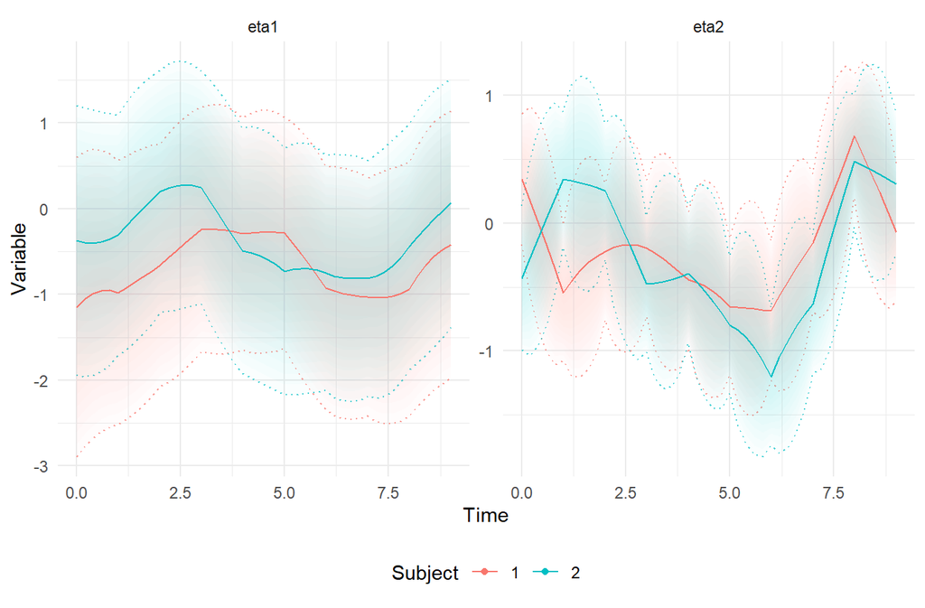

```r
plot(ctKalman(f2, subjects = 1:2, timestep = .2), kalmanvec = 'etasmooth')
```

# State-dependent measurement

A `LAMBDA` or `MANIFESTVAR` cell need not be a constant. Writing a latent process name into the cell makes it an expression evaluated at the current state, so an instrument can become more or less sensitive, or noisier, as the process moves.

Free parameters used inside such an expression have to live in the `PARS` matrix: a cell containing an expression is the specification itself rather than a labelled parameter, so ctsem resolves names appearing in it against `PARS`. `PARS` entries are identity-transformed and unbounded, which is why the residual below is written as `exp(...)` — that is what keeps a standard deviation positive.

Data where the second indicator’s loading rises with the process, and the first indicator’s residual standard deviation rises with it too:

```r
set.seed(9)
gensd <- ctModel(type = 'ct', n.latent = 1, n.manifest = 2,
  manifestNames = c('y1', 'y2'), latentNames = 'eta1',
  LAMBDA = matrix(c(1, '0.9 + 0.35 * eta1'), 2, 1),
  MANIFESTVAR = matrix(c('exp(-0.7 + 0.3 * eta1)', 0,
    0, 0.8), 2, 2),
  DRIFT = matrix(-0.4), DIFFUSION = matrix(1.5), T0VAR = matrix(1.7),
  T0MEANS = matrix(0), CINT = matrix(0),
  MANIFESTMEANS = matrix(c(0, 0.5), 2, 1), Tpoints = 10)

dsd <- data.frame(ctGenerate(gensd, n = 60, Tpoints = 10,
  backend = 'julia'))
head(dsd, 3)
```

```
#>   id time        y1         y2
#> 1  1    0 -1.617416  0.1401635
#> 2  1    1 -1.797942 -0.4742866
#> 3  1    2 -1.316891 -0.6378433
```

The estimation model writes the same two expressions, with parameter names in place of the generating constants:

```r
msd <- ctModel(type = 'ct', n.latent = 1, n.manifest = 2,
  manifestNames = c('y1', 'y2'), latentNames = 'eta1',
  LAMBDA = matrix(c(1, 'lam0 + lamslope * eta1'), 2, 1),
  MANIFESTVAR = matrix(c('exp(logsd0 + logsdslope * eta1)', 0,
    0, 'mvar_y2'), 2, 2),
  MANIFESTMEANS = matrix(c(0, 'mm_y2'), 2, 1),
  CINT = matrix(0), T0MEANS = matrix(0),
  PARS = matrix(c('lam0', 'lamslope', 'logsd0', 'logsdslope'), 4, 1))
msd$pars$indvarying <- FALSE

fsd <- ctFit(dsd, msd, backend = 'julia', cores = 2)
summary(fsd)$popmeans
```

```
#>              mean    sd   2.5%    50%  97.5%
#> drift_eta1 -0.449 0.060 -0.574 -0.448 -0.347
#> diff_eta1   1.538 0.086  1.373  1.535  1.714
#> mvar_y2     1.189 0.042  1.106  1.188  1.270
#> mm_y2       1.140 0.054  1.036  1.139  1.246
#> T0var_eta1  1.992 0.190  1.650  1.987  2.384
#> lam0        0.803 0.040  0.723  0.803  0.879
#> lamslope    0.234 0.026  0.183  0.234  0.286
#> logsd0     -0.761 0.177 -1.110 -0.762 -0.426
#> logsdslope  0.207 0.105  0.020  0.205  0.403
```

Against the generating values:

```r
psd <- summary(fsd)$popmeans
sdpars <- c('lam0', 'lamslope', 'logsd0', 'logsdslope')
data.frame(
  parameter = sdpars,
  meaning = c('loading on y2 at eta1 = 0',
    'change in that loading per unit of eta1',
    'log residual sd of y1 at eta1 = 0',
    'change in that log sd per unit of eta1'),
  truth = c(0.9, 0.35, -0.7, 0.3),
  estimate = psd[sdpars, 'mean'],
  row.names = NULL)
```

```
#>    parameter                                 meaning truth estimate
#> 1       lam0               loading on y2 at eta1 = 0  0.90    0.803
#> 2   lamslope change in that loading per unit of eta1  0.35    0.234
#> 3     logsd0       log residual sd of y1 at eta1 = 0 -0.70   -0.761
#> 4 logsdslope  change in that log sd per unit of eta1  0.30    0.207
```

`ctModelIsNonlinear()` reports that such a model has cells with no single value, so every summary of it is a reading at one particular state:

```r
ctModelIsNonlinear(fsd)
```

```
#> [1] TRUE
```

Which is why the honest picture of a state-dependent model is a curve rather than a number. `ctStateDependencePlot()` finds the cells that actually move — by materialising every model matrix across a grid of states and keeping the ones whose value changes, so dependence arriving indirectly, through a `PARS` entry or through a covariance built from a dependent cell, is caught too — and draws each of them against the process:

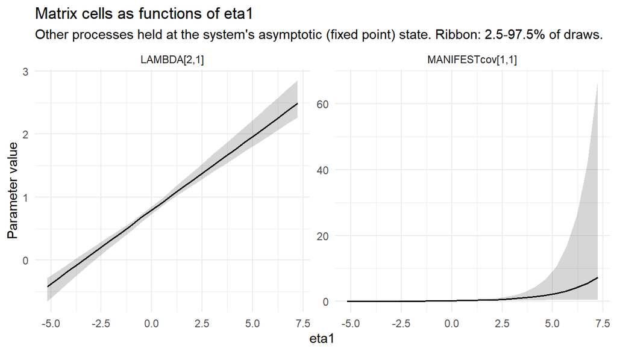

```r
ctStateDependencePlot(fsd, along = 'eta1', nsamples = 30)
```

One panel is the loading on `y2`, rising with `eta1`. The other is the residual *variance* of `y1` — `MANIFESTcov` rather than `MANIFESTVAR`, since that is the covariance the filter actually uses — rising with it as well. A `summary()` of this model reports one point from each of those curves.

Only `LAMBDA` and `MANIFESTVAR` are state-dependent here, but the same mechanism applies to `MANIFESTMEANS`, and on the dynamic side to `DRIFT`, `DIFFUSION` and `CINT`.

# Summary

- `manifesttype` picks the observation model per indicator: `0` continuous, `1` binary, `2` ordinal (with `ncategories`), `3` count, `4` censored (with `censormin` and `censormax`). Everything but `0` needs `backend = 'julia'`.
- Continuous, count and censored indicators each have a free `MANIFESTVAR` diagonal, meaning a measurement error variance, a log-scale dispersion, and the variance inside the limits respectively. Binary and ordinal have none; fix theirs to zero.
- An ordinal indicator’s location is its `MANIFESTMEANS`, like every other indicator’s. `THRESHOLDS` pins the first threshold at zero and estimates the K-2 gaps, so a person-level shift of the whole category scale is one random effect on the mean rather than one per boundary.
- Anchor the latent scale exactly once: a fixed loading, or a fixed `DIFFUSION`. With no Gaussian indicator on a process it has to be the loadings.
- A count indicator’s loading sets how far its log rate travels. Keep that range moderate – the filter’s Gaussian summary of a Poisson update degrades once the rate swings over orders of magnitude, and the dynamic parameters come back attenuated.
- Types can be mixed freely, on one process or across several.
- A `LAMBDA` or `MANIFESTVAR` cell written as an expression in a latent process name is evaluated at the current state; free parameters inside it go in `PARS`, and `ctStateDependencePlot()` shows what the result claims.